# RinActionChap05 Advanced data management

Tony

2016年1月1日

### Numerical and character functions

#### Mathematical function

- abs(x)
- sqrt(x)
- ceiling(3.5) = 4
- floor(3.5) = 3
- trunc(3.5) = 3
- round(3.456, digits=2) = 3.46
- signif(3.475, digits=2) = 3.5
- cos(x), sin(x), tan(x)
- acos, asin, atan
- cosh, sinh tanh
- acosh, asinh, atanh
- log(x, base=n)
- log(x) natural logarithm
- log10(x)
- exp(x)

#### Probability functions

In R, probality function take the form {dpqr}sitribution_abbreviation()

- d = density
- p = distribution function
- q = quantile function
- r = random generation(random deviates)

| Distribution | Abbreviation | Distribution | Abbreviation |
| --- | --- | --- | --- |
| Beta | beta | Logistic | logis |
| Binomial | binom | Multinomial | multinom |
| Cauchy | cauchy | Negative binomial | nbinom |
| Chi-squared (noncentral) | chisq | Normal | norm |
| Exponential | exp | Poisson | pois |
| F | f | Wilcoxon Signed Rank | signrank |
| Gamma | gamma | T | t |
| Geometric | geom | Uniform | unif |
| Hypergeometric | hyper | Weibull | weibull |
| Lognormal | lnorm | Wilcoxon Rank Sum | wilcox |

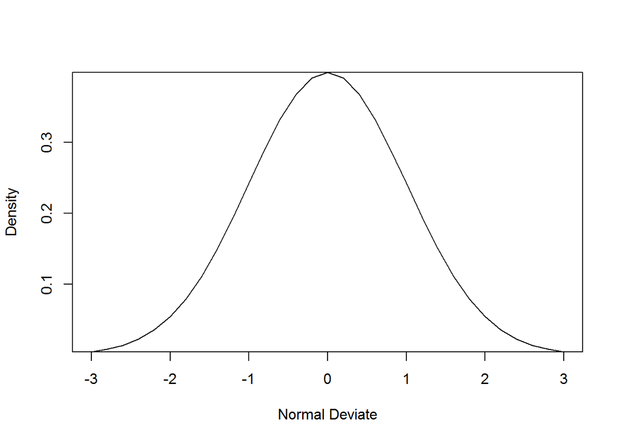

```r
x <- pretty(c(-3, 3), 30)
y <- dnorm(x)
plot(x, y,
     type = "l",
     xlab = "Normal Deviate",
     ylab = "Density",
     yaxs = "i"
     )
```

```r
runif(5)
```

```
## [1] 0.78282592 0.99115066 0.06093267 0.19301868 0.86403092
```

```r
# by setting the seed manually, you're able to reproduce your results
set.seed(1234)
runif(5)
```

```
## [1] 0.1137034 0.6222994 0.6092747 0.6233794 0.8609154
```

```r
set.seed(1234)
runif(5)
```

```
## [1] 0.1137034 0.6222994 0.6092747 0.6233794 0.8609154
```

#### Character functions

- nchar(x) count the number of characters of x
- substr(x, start, stop): x <- “abcdef” substr(x, 2, 4) returns “bcd” substr(x, 2, 4) <- “2222”, now x is “a222ef”
- grep(pattern, x, ignore.case=FALSE, fixed=FALSE) fixed=FALSE pattern is a regular expression
- sub(pattern, x, replacement, x, ignore.case=FALSE, fixed=FALSE)
- strsplit(x, split, fixed=FALSE)
- paste(… sep=“”) paste(“x”, 1:3, sep=“M”) returns c(“xM1”, “xM2”, “xM3”)
- toupper(x)
- tolower(x)

#### Other userful functions

```r
a <- 1:3
length(a)
```

```
## [1] 3
```

```r
seq(1,10,2)
```

```
## [1] 1 3 5 7 9
```

```r
rep(1:3, 2)
```

```
## [1] 1 2 3 1 2 3
```

```r
cut(rep(1:3, 2), 2)
```

```
## [1] (0.998,2] (0.998,2] (2,3]     (0.998,2] (0.998,2] (2,3]
## Levels: (0.998,2] (2,3]
```

```r
pretty(rep(1:10,2), 3)
```

```
## [1]  0  5 10
```

```r
#cat(..., file = "myfile", append = FALSE)
```

#### Control flow

```r
for (i in 1:3) print("Hello")
```

```
## [1] "Hello"
## [1] "Hello"
## [1] "Hello"
```

```r
i <- 3
while (i >0)
{
  print("Hello")
  i <- i-1
}
```

```
## [1] "Hello"
## [1] "Hello"
## [1] "Hello"
```

```r
ifelse (TRUE, print("1"), print("0"))
```

```
## [1] "1"
```

```
## [1] "1"
```

```r
feelings <-c("sad", "afraid")
for (i in feelings)
  print(
    switch(i,
           happy = "h",
           afraid = "A",
           sad = "s"
           )
  )
```

```
## [1] "s"
## [1] "A"
```

#### User-written functions

```r
mystats <- function(x, parametric=TRUE, print=FALSE)
{
  if (parametric)
  {
    center <- mean(x);
    spread <- sd(x)
  }
  else
  {
    center <- median(x);
    spread <- mad(x)
  }

  if (print & parametric)
  {
    cat("Mean=", center, "\n", "SD=", spread, "\n" )
  }
  else if (print & !parametric)
  {

    cat("Median=", center, "\n", "MAD=", spread, "\n" )
  }
  result <- list(center=center, spread=spread)
  return(result)
}

set.seed(1234)
x <- rnorm(500)
y <- mystats(x)
y
```

```
## $center
## [1] 0.001838821
##
## $spread
## [1] 1.034814
```

#### Aggregation and restructuring

```r
cars <- mtcars[1:5, 1:4]
t(cars)
```

```
##      Mazda RX4 Mazda RX4 Wag Datsun 710 Hornet 4 Drive Hornet Sportabout
## mpg         21            21       22.8           21.4              18.7
## cyl          6             6        4.0            6.0               8.0
## disp       160           160      108.0          258.0             360.0
## hp         110           110       93.0          110.0             175.0
```

```r
options(digits = 3)
attach(mtcars)
aggdata <- aggregate(mtcars, by=list(cyl, gear), FUN=mean, na.rm=TRUE)
aggdata
```

```
##   Group.1 Group.2  mpg cyl disp  hp drat   wt qsec  vs   am gear carb
## 1       4       3 21.5   4  120  97 3.70 2.46 20.0 1.0 0.00    3 1.00
## 2       6       3 19.8   6  242 108 2.92 3.34 19.8 1.0 0.00    3 1.00
## 3       8       3 15.1   8  358 194 3.12 4.10 17.1 0.0 0.00    3 3.08
## 4       4       4 26.9   4  103  76 4.11 2.38 19.6 1.0 0.75    4 1.50
## 5       6       4 19.8   6  164 116 3.91 3.09 17.7 0.5 0.50    4 4.00
## 6       4       5 28.2   4  108 102 4.10 1.83 16.8 0.5 1.00    5 2.00
## 7       6       5 19.7   6  145 175 3.62 2.77 15.5 0.0 1.00    5 6.00
## 8       8       5 15.4   8  326 300 3.88 3.37 14.6 0.0 1.00    5 6.00
```

```r
# reshape package
library(reshape)
# md <- melt(mydata, id=(c("id", "time")))
# newdata <- cast(md, fomula, FUN)
```